# Chess Elo Prediction — v2 (Scale Edition)

Predicts player Elo from game moves + clock usage.

- **Distribution explorer** before picking time-control
- Fast original loader with chunked streaming for 40M+ games
- Board-aware features via `chess_features_final.py`
- LightGBM **or** XGBoost (with optional GPU via GTX 970)
- Dedicated hyperparameter search subset (configurable fraction)
- Full diagnostic plots + HTML export of all outputs

```python
# pip install chess zstandard lightgbm xgboost pandas scikit-learn matplotlib joblib nbconvert
import io, re, time, os, gc, warnings
from datetime import datetime
warnings.filterwarnings('ignore')

import numpy as np
import pandas as pd
import matplotlib.pyplot as plt
import matplotlib.ticker as mticker
import zstandard as zstd

import lightgbm as lgb
import xgboost as xgb

from sklearn.compose import ColumnTransformer
from sklearn.impute import SimpleImputer
from sklearn.model_selection import train_test_split, RandomizedSearchCV
from sklearn.metrics import mean_absolute_error, root_mean_squared_error
from sklearn.inspection import permutation_importance
from sklearn.preprocessing import OneHotEncoder
from scipy.stats import randint, uniform
from joblib import Parallel, delayed

from chess_features_final import extract_features_dataframe, compute_elo_sample_weights

print('All imports OK')
print(f'LightGBM {lgb.__version__}  |  XGBoost {xgb.__version__}')
```

```
All imports OK
LightGBM 4.6.0  |  XGBoost 3.2.0
```

## ⚙️ Configuration — edit everything here, nowhere else

```python
# ═══════════════════════════════════════════════════════════════════════════════
#  CONFIGURATION — edit everything here, nowhere else
# ═══════════════════════════════════════════════════════════════════════════════

DATA_PATH    = "../../data/villads_data/lichess_db_standard_rated_2017-11.pgn.zst"
MAX_GAMES    = 1_000_000      # total games to load; use None for all
RANDOM_STATE = 42
N_JOBS       = -1             # -1 = all CPU cores for parallel feature extraction

# ── Distribution explorer (run BEFORE choosing time-control) ──────────────────
# Set to True to plot Elo + player count distributions across all time controls
# before any filtering. Slows loading slightly (no TC filter applied yet).
RUN_DISTRIBUTION_EXPLORER = False
DIST_SAMPLE               = 200_000   # use a sample for fast distribution plots
                                      # (None = full dataset, slower)

# ── splits ─────────────────────────────────────────────────────────────────────
VAL_SIZE     = 0.10           # fraction of total data for validation
TEST_SIZE    = 0.10           # fraction of total data for test (rest = train)

# ── hyperparameter search subset ──────────────────────────────────────────────
# Fraction of training data to use for hyperparam search (keeps it fast).
# 0.10 = 10% of training data used for RandomizedSearchCV.
HYPERPARAM_SUBSET_FRACTION = 0.10

# ── time-control filter ───────────────────────────────────────────────────────
# Set to None to keep all games, or e.g. 600 to keep only 10-min games.
FILTER_BASE_SECONDS = 180

# ── data quality filters ──────────────────────────────────────────────────────
FILTER_SHORT_GAMES   = True
MIN_TOTAL_PLIES      = 12
EXCLUDE_TERMINATIONS = {"Abandoned", "Unterminated"}

# ── feature groups ─────────────────────────────────────────────────────────────
FEATURE_GROUPS = {
    'structure':  True,
    'checks':     True,
    'captures':   True,
    'castling':   True,
    'style':      True,
    'clock':      True,
    'engine':     False,   # needs [%eval] tags in PGN
    'meta':       False,
}

ADD_TIME_CONTROL_NUMERIC = True
ECO_COARSE_LEVEL = "letter"   # "letter" or None

# ── model backend ──────────────────────────────────────────────────────────────
# MODEL_BACKEND: "lightgbm" or "xgboost"
MODEL_BACKEND = "lightgbm"

# ── GPU settings ───────────────────────────────────────────────────────────────
# GTX 970 has 4 GB VRAM. Set USE_GPU=True to attempt GPU training.
# The notebook will benchmark GPU vs CPU on a small sample and auto-disable
# if GPU is slower (common for small datasets; beneficial at 5M+ rows).
USE_GPU           = True     # set True to attempt GTX 970 GPU training
GPU_AUTO_DISABLE  = False      # if True: times GPU vs CPU; keeps whichever is faster
GPU_DEVICE_ID     = 0

# ── LightGBM params ────────────────────────────────────────────────────────────
LGBM_PARAMS = {
    'n_estimators':      800,
    'learning_rate':     0.05,
    'num_leaves':        127,
    'min_child_samples': 50,
    'subsample':         0.8,
    'colsample_bytree':  0.8,
    'random_state':      RANDOM_STATE,
    'verbose':           -1,
    'n_jobs':            N_JOBS,
}

# ── XGBoost params ─────────────────────────────────────────────────────────────
XGB_PARAMS = {
    'n_estimators':      800,
    'learning_rate':     0.05,
    'max_depth':         6,
    'min_child_weight':  50,
    'subsample':         0.8,
    'colsample_bytree':  0.8,
    'random_state':      RANDOM_STATE,
    'verbosity':         0,
    'n_jobs':            N_JOBS,
    'tree_method':       'hist',   # fast histogram method
    'early_stopping_rounds': 50,
}

# ── hyperparam search ──────────────────────────────────────────────────────────
RUN_HYPERPARAM_SEARCH   = False
HYPERPARAM_N_ITER       = 20
HYPERPARAM_CV_FOLDS     = 3
LGBM_SEARCH_SPACE = {
    'n_estimators':      randint(300, 1000),
    'learning_rate':     uniform(0.01, 0.09),
    'num_leaves':        randint(63, 255),
    'min_child_samples': randint(20, 100),
    'subsample':         uniform(0.6, 0.4),
    'colsample_bytree':  uniform(0.6, 0.4),
}
XGB_SEARCH_SPACE = {
    'n_estimators':      randint(300, 1000),
    'learning_rate':     uniform(0.01, 0.09),
    'max_depth':         randint(4, 9),
    'min_child_weight':  randint(20, 100),
    'subsample':         uniform(0.6, 0.4),
    'colsample_bytree':  uniform(0.6, 0.4),
}

# ── pretrained models ──────────────────────────────────────────────────────────
LOAD_PRETRAINED_MODELS = False
PRETRAINED_WHITE_PATH  = None
PRETRAINED_BLACK_PATH  = None

# ── importance ─────────────────────────────────────────────────────────────────
RUN_PERM_IMPORTANCE       = True
FEATURE_IMPORTANCE_METHOD = "gain"   # "gain", "split", or "permutation"
PERM_N_REPEATS            = 5
TOP_N_FEATURES            = 15
RETRAIN_TOP_N             = False

# ── output ─────────────────────────────────────────────────────────────────────
VERBOSE_PLOTS    = True
MODEL_SAVE_NAME  = f'elo_{MODEL_BACKEND}_{MAX_GAMES}'
MODEL_SAVE_NOTES = '600s_scale'
ELO_BINS         = [0, 1000, 1200, 1400, 1600, 1800, 2000, 2200, 2500, 4000]

# ── HTML export ─────────────────────────────────────────────────────────────────
# At the END of the notebook, run: export_notebook_to_html(__file__)
# or manually: jupyter nbconvert --to html <this_notebook>.ipynb
EXPORT_HTML = True   # auto-export after last cell if running as a script

# ═══════════════════════════════════════════════════════════════════════════════
#  Derived feature lists — built from FEATURE_GROUPS
# ═══════════════════════════════════════════════════════════════════════════════

_BOARD_FEATURES = {
    'structure': ['total_ply_count', 'material_balance_end', 'result_encoded'],
    'checks':    ['checks_given_white', 'checks_given_black',
                  'check_density_white', 'check_density_black'],
    'captures':  ['first_capture_move_white', 'first_capture_move_black',
                  'pawn_captures_total', 'piece_captures_total', 'capture_density'],
    'castling':  ['castle_move_white', 'castle_move_black'],
    'style':     ['consec_same_piece_white', 'consec_same_piece_black',
                  'queen_moves_before_10', 'white_territory_depth', 'black_territory_depth',
                  'promotions', 'en_passant_captures',
                  'legal_moves_white_move5', 'legal_moves_black_move5'],
    'engine':    ['acpl_white', 'inaccuracy_count_white', 'mistake_count_white',
                  'blunder_count_white', 'blunder_density_white',
                  'acpl_black', 'inaccuracy_count_black', 'mistake_count_black',
                  'blunder_count_black', 'blunder_density_black'],
}
_CLOCK_FEATURES = [
    'avg_time_norm_white', 'std_time_norm_white', 'max_time_norm_white',
    'time_pressure_white', 'opening_pace_norm_white', 'clock_remaining_norm_white',
    'opening_time_norm_white', 'endgame_time_norm_white', 'time_spent_trend_norm_white',
    'avg_time_norm_black', 'std_time_norm_black', 'max_time_norm_black',
    'time_pressure_black', 'opening_pace_norm_black', 'clock_remaining_norm_black',
    'opening_time_norm_black', 'endgame_time_norm_black', 'time_spent_trend_norm_black',
]
_CASTLE_CAT = ['castle_side_white', 'castle_side_black'] if FEATURE_GROUPS['castling'] else []
_META_CAT   = []
if FEATURE_GROUPS['meta']:
    _META_CAT = ['TimeControl', 'ECO_Group'] if ECO_COARSE_LEVEL == 'letter' else ['TimeControl', 'ECO']
_TC_NUMERIC = ['tc_base', 'tc_increment'] if ADD_TIME_CONTROL_NUMERIC else []

NUMERIC_FEATURES = []
for grp, cols in _BOARD_FEATURES.items():
    if FEATURE_GROUPS.get(grp, False):
        NUMERIC_FEATURES += cols
if FEATURE_GROUPS['clock']:
    NUMERIC_FEATURES += _CLOCK_FEATURES
NUMERIC_FEATURES += _TC_NUMERIC
CATEGORICAL_FEATURES = _CASTLE_CAT + _META_CAT

print(f'Backend           : {MODEL_BACKEND}')
print(f'GPU               : USE_GPU={USE_GPU}  auto-disable={GPU_AUTO_DISABLE}')
print(f'Numeric features  : {len(NUMERIC_FEATURES)}')
print(f'Categorical groups: {CATEGORICAL_FEATURES[:4]}')
print(f'Feature groups    : {dict(FEATURE_GROUPS)}')
```

```
Backend           : lightgbm
GPU               : USE_GPU=True  auto-disable=False
Numeric features  : 43
Categorical groups: ['castle_side_white', 'castle_side_black']
Feature groups    : {'structure': True, 'checks': True, 'captures': True, 'castling': True, 'style': True, 'clock': True, 'engine': False, 'meta': False}
```

## 1 · Load data

Fast streaming loader — handles files too large for RAM.

```python
games_list = []
dctx = zstd.ZstdDecompressor()

t0 = time.time()
with open(DATA_PATH, 'rb') as compressed_file:
    with dctx.stream_reader(compressed_file) as reader:
        text_stream = io.TextIOWrapper(reader, encoding='utf-8')
        current_game = {}
        for line in text_stream:
            line = line.strip()
            if line.startswith('['):
                tag = line.split(' ')[0][1:]
                val = line.split('"')[1]
                if tag in ('WhiteElo', 'BlackElo', 'TimeControl', 'ECO',
                           'Termination', 'Result'):
                    current_game[tag] = val
            elif line.startswith('1.'):
                current_game['Moves'] = line
                if 'WhiteElo' in current_game and 'BlackElo' in current_game:
                    games_list.append(current_game)
                current_game = {}
                if MAX_GAMES and len(games_list) >= MAX_GAMES:
                    break

df_raw = pd.DataFrame(games_list)
df_raw['WhiteElo'] = pd.to_numeric(df_raw['WhiteElo'], errors='coerce')
df_raw['BlackElo'] = pd.to_numeric(df_raw['BlackElo'], errors='coerce')
df_raw = df_raw.dropna(subset=['WhiteElo', 'BlackElo']).copy()
df_raw['WhiteElo'] = df_raw['WhiteElo'].astype(int)
df_raw['BlackElo'] = df_raw['BlackElo'].astype(int)
df_raw['Moves']    = df_raw['Moves'].fillna('').astype(str)

load_time = time.time() - t0
print(f'Loaded {len(df_raw):,} games in {load_time:.1f}s')
df_raw.head(3)
```

```
Loaded 1,000,000 games in 77.2s
```

|  | Result | WhiteElo | BlackElo | ECO | TimeControl | Termination | Moves |
| --- | --- | --- | --- | --- | --- | --- | --- |
| 0 | 0-1 | 1391 | 1411 | C20 | 600+0 | Normal | 1. e4 { [%clk 0:10:00] } e5 { [%clk 0:05:00] }... |
| 1 | 0-1 | 1626 | 1620 | B56 | 180+0 | Time forfeit | 1. e4 { [%clk 0:03:00] } c5 { [%clk 0:03:00] }... |
| 2 | 1-0 | 1374 | 1350 | B30 | 600+0 | Normal | 1. e4 { [%clk 0:10:00] } c5 { [%clk 0:05:00] }... |

## 2 · Distribution Explorer 📊

Run this **before** picking a time-control filter.  
Shows Elo distribution and game counts per TC bucket so you can make an informed choice.

```python
if RUN_DISTRIBUTION_EXPLORER and 'TimeControl' in df_raw.columns:
    _df_dist = df_raw
    if DIST_SAMPLE and len(_df_dist) > DIST_SAMPLE:
        _df_dist = _df_dist.sample(DIST_SAMPLE, random_state=RANDOM_STATE)
        print(f'Distribution explorer using {DIST_SAMPLE:,}-game sample')

    # ── parse TC base seconds ──────────────────────────────────────────────
    _tc_base_all = (
        _df_dist['TimeControl'].astype(str)
        .str.extract(r'^(\d+)\+')[0]
        .astype(float)
    )
    _df_dist = _df_dist.copy()
    _df_dist['tc_base_s'] = _tc_base_all

    # label mapping
    _TC_LABELS = {
        30: 'UltraBullet (30s)', 60: 'Bullet (1m)', 120: 'Bullet (2m)',
        180: 'Blitz (3m)', 300: 'Blitz (5m)', 600: 'Rapid (10m)',
        900: 'Rapid (15m)', 1800: 'Classical (30m)', 3600: 'Classical (60m)',
    }
    _df_dist['tc_label'] = _df_dist['tc_base_s'].map(
        lambda x: _TC_LABELS.get(x, f'{int(x)}s' if not pd.isna(x) else 'Unknown')
    )

    # ── Fig 1: game count per time control ────────────────────────────────
    _tc_counts = _df_dist['tc_label'].value_counts().sort_values(ascending=False)
    fig, ax = plt.subplots(figsize=(12, 4))
    bars = ax.bar(_tc_counts.index, _tc_counts.values, color='#3b82f6', alpha=0.85, edgecolor='none')
    ax.bar_label(bars, fmt=lambda x: f'{int(x):,}', fontsize=8, padding=3)
    ax.set_title('Game count by time control', fontweight='bold', fontsize=13)
    ax.set_xlabel('Time control'); ax.set_ylabel('Games in sample')
    ax.tick_params(axis='x', rotation=35)
    ax.yaxis.set_major_formatter(mticker.FuncFormatter(lambda x, _: f'{int(x):,}'))
    plt.tight_layout()
    plt.show()
    print('Fig 1: game count per TC saved')

    # ── Fig 2: Elo distribution per top-6 time controls ───────────────────
    _top_tcs = _tc_counts.head(6).index.tolist()
    fig, axes = plt.subplots(2, 3, figsize=(16, 8))
    axes = axes.flatten()
    _COLORS = ['#3b82f6','#f59e0b','#10b981','#ef4444','#8b5cf6','#ec4899']
    for ax, tc, col in zip(axes, _top_tcs, _COLORS):
        subset = _df_dist[_df_dist['tc_label'] == tc]
        all_elo = pd.concat([subset['WhiteElo'], subset['BlackElo']])
        ax.hist(all_elo, bins=50, color=col, alpha=0.8, edgecolor='none')
        ax.axvline(all_elo.median(), color='black', lw=1.5, ls='--',
                   label=f'Median {all_elo.median():.0f}')
        ax.set_title(f'{tc}  (n={len(subset):,})', fontweight='bold')
        ax.set_xlabel('Elo'); ax.set_ylabel('Count')
        ax.legend(fontsize=8)
        ax.grid(axis='y', alpha=0.3)
    plt.suptitle('Elo distribution by time control', fontsize=14, fontweight='bold', y=1.01)
    plt.tight_layout()
    plt.show()
    print('Fig 2: Elo distributions per TC saved')

    # ── Fig 3: median / IQR Elo summary table ─────────────────────────────
    _summary_rows = []
    for tc in _tc_counts.head(10).index:
        subset = _df_dist[_df_dist['tc_label'] == tc]
        all_elo = pd.concat([subset['WhiteElo'], subset['BlackElo']])
        _summary_rows.append({
            'TC': tc,
            'Games': len(subset),
            'Median Elo': int(all_elo.median()),
            'P10': int(all_elo.quantile(0.10)),
            'P25': int(all_elo.quantile(0.25)),
            'P75': int(all_elo.quantile(0.75)),
            'P90': int(all_elo.quantile(0.90)),
            '% > 2000': f'{(all_elo > 2000).mean()*100:.1f}%',
        })
    _summary_df = pd.DataFrame(_summary_rows).set_index('TC')

    # ── Fig 4: Elo imbalance — are high-Elo games underrepresented? ────────
    fig, ax = plt.subplots(figsize=(12, 4))
    all_elo_full = pd.concat([_df_dist['WhiteElo'], _df_dist['BlackElo']])
    ax.hist(all_elo_full, bins=80, color='#64748b', alpha=0.8, edgecolor='none')
    for b in ELO_BINS[1:-1]:
        ax.axvline(b, color='#ef4444', lw=0.9, ls='--', alpha=0.7)
    ax.set_title('Overall Elo distribution with sample-weight bin boundaries', fontweight='bold')
    ax.set_xlabel('Elo'); ax.set_ylabel('Count')
    ax.text(0.98, 0.92, 'Red dashes = weight bins', transform=ax.transAxes,
            ha='right', fontsize=8, color='#ef4444')
    ax.yaxis.set_major_formatter(mticker.FuncFormatter(lambda x, _: f'{int(x):,}'))
    plt.tight_layout()
    plt.show()

    # ── Fig 5: per-bin count → reveal imbalance ────────────────────────────
    _bin_counts = pd.cut(all_elo_full, bins=ELO_BINS, right=True).value_counts().sort_index()
    fig, axes = plt.subplots(1, 2, figsize=(14, 4))

    axes[0].bar(range(len(_bin_counts)), _bin_counts.values, color='#3b82f6', alpha=0.85, edgecolor='none')
    axes[0].set_xticks(range(len(_bin_counts)))
    axes[0].set_xticklabels([str(b) for b in _bin_counts.index], rotation=35, ha='right', fontsize=7)
    axes[0].set_title('Raw game count per Elo bin', fontweight='bold')
    axes[0].set_ylabel('Count')
    axes[0].yaxis.set_major_formatter(mticker.FuncFormatter(lambda x, _: f'{int(x):,}'))

    # inverse-frequency weights (what compute_elo_sample_weights does)
    _inv_freq = 1.0 / _bin_counts
    _norm_w   = _inv_freq / _inv_freq.mean()
    axes[1].bar(range(len(_norm_w)), _norm_w.values, color='#f59e0b', alpha=0.85, edgecolor='none')
    axes[1].set_xticks(range(len(_norm_w)))
    axes[1].set_xticklabels([str(b) for b in _norm_w.index], rotation=35, ha='right', fontsize=7)
    axes[1].set_title('Relative sample weight per Elo bin\n(inverse-frequency, normalised to mean=1)',
                      fontweight='bold')
    axes[1].set_ylabel('Weight (1 = average)')
    axes[1].axhline(1, color='black', lw=1, ls='--', alpha=0.5)

    _note = (
        "⚠️  High-Elo bins get much larger weights (fewer games).\n"
        "   This corrects for under-representation but weights can get very large.\n"
        "   Weights are clipped at 8× in the training cell (see WEIGHT_CLIP)."
    )
    for ax in axes:
        ax.grid(axis='y', alpha=0.3)
    plt.suptitle('Sample weight analysis — imbalance & correction', fontsize=13, fontweight='bold')
    plt.tight_layout()
    plt.show()
    print(_note)
    print()

    # ── print summary table ────────────────────────────────────────────────
    print('=== Elo summary by time control ===')
    print(_summary_df.to_string())
    print()
    print(f'▶  Suggested filter: set FILTER_BASE_SECONDS to one of:')
    for tc_s, cnt in _tc_counts.head(5).items():
        # extract numeric seconds from label
        _match = [k for k, v in _TC_LABELS.items() if v == tc_s]
        _sec   = _match[0] if _match else '?'
        print(f'   {_sec:>6}  ({tc_s:30s})  {cnt:>8,} games in sample')

else:
    print('Distribution explorer skipped (RUN_DISTRIBUTION_EXPLORER=False)')
```

```
Distribution explorer skipped (RUN_DISTRIBUTION_EXPLORER=False)
```

## 3 · Apply filters

```python
# ── time-control filter ────────────────────────────────────────────────────────
if FILTER_BASE_SECONDS is not None:
    _tc_base = (
        df_raw['TimeControl'].astype(str)
        .str.extract(r'^(\d+)\+')[0]
        .astype(float)
    )
    df_raw = df_raw[_tc_base == FILTER_BASE_SECONDS].copy().reset_index(drop=True)
    print(f'After TC filter ({FILTER_BASE_SECONDS}s): {len(df_raw):,} games')
else:
    print('No TC filter applied')

# ── termination filter ─────────────────────────────────────────────────────────
if EXCLUDE_TERMINATIONS and 'Termination' in df_raw.columns:
    before = len(df_raw)
    df_raw = df_raw[~df_raw['Termination'].isin(EXCLUDE_TERMINATIONS)].copy().reset_index(drop=True)
    print(f'After termination filter: {len(df_raw):,} games (dropped {before-len(df_raw):,})')

# ── TC numeric features ────────────────────────────────────────────────────────
if ADD_TIME_CONTROL_NUMERIC and 'TimeControl' in df_raw.columns:
    _tc = df_raw['TimeControl'].astype(str).str.extract(r'^(\d+)\+(\d+)')
    df_raw['tc_base']      = pd.to_numeric(_tc[0], errors='coerce').fillna(0).astype(float)
    df_raw['tc_increment'] = pd.to_numeric(_tc[1], errors='coerce').fillna(0).astype(float)

print(f'Games after all filters: {len(df_raw):,}')
df_raw.head(3)
```

```
After TC filter (180s): 236,603 games
After termination filter: 236,036 games (dropped 567)
Games after all filters: 236,036
```

|  | Result | WhiteElo | BlackElo | ECO | TimeControl | Termination | Moves | tc_base | tc_increment |
| --- | --- | --- | --- | --- | --- | --- | --- | --- | --- |
| 0 | 0-1 | 1626 | 1620 | B56 | 180+0 | Time forfeit | 1. e4 { [%clk 0:03:00] } c5 { [%clk 0:03:00] }... | 180.0 | 0.0 |
| 1 | 1-0 | 1876 | 1865 | A43 | 180+2 | Time forfeit | 1. d4 { [%clk 0:03:00] } c5 { [%clk 0:03:00] }... | 180.0 | 2.0 |
| 2 | 1/2-1/2 | 1969 | 2003 | C00 | 180+0 | Normal | 1. e4 { [%clk 0:03:00] } e6 { [%clk 0:03:00] }... | 180.0 | 0.0 |

## 4 · Clock features (fast regex)

```python
_CLK_RE = re.compile(r'\[%clk\s+(\d+):(\d+):(\d+)\]')

def parse_clock_features(moves_string: str, time_control: str = '?') -> dict:
    clocks = [int(h)*3600 + int(m)*60 + int(s)
              for h, m, s in _CLK_RE.findall(moves_string)]
    clk_w, clk_b = clocks[0::2], clocks[1::2]
    tc_m      = re.match(r'(\d+)\+(\d+)', str(time_control))
    base      = int(tc_m.group(1)) if tc_m else None
    increment = int(tc_m.group(2)) if tc_m else 0
    norm      = base if base else 1

    def _spent(seq, start):
        out, prev = [], start
        for c in seq:
            if prev is not None:
                s = prev - c + increment
                if s >= 0: out.append(s)
            prev = c
        return out

    sw = _spent(clk_w, base)
    sb = _spent(clk_b, base)

    def _stats(seq):
        if not seq: return 0., 0., 0.
        a = np.array(seq)
        return float(a.mean()), float(a.std()), float(a.max())

    def _trend(seq):
        if len(seq) < 2: return 0.0
        x = np.arange(len(seq))
        return float(np.polyfit(x, np.array(seq, dtype=float), 1)[0])

    def _window_mean(seq, n=10, which='first'):
        if not seq: return 0.0
        return float(np.mean(seq[:n] if which == 'first' else seq[-n:]))

    aw, sw2, mw = _stats(sw)
    ab, sb2, mb = _stats(sb)

    return {
        'avg_time_norm_white':         aw / norm,
        'std_time_norm_white':         sw2 / norm,
        'max_time_norm_white':         mw / norm,
        'time_pressure_white':         sum(1 for c in clk_w if c < 10),
        'opening_pace_norm_white':     (np.mean(sw[:10]) if sw else 0.) / norm,
        'clock_remaining_norm_white':  (clk_w[-1] / norm) if clk_w else 0.,
        'opening_time_norm_white':     _window_mean(sw, 10, 'first') / norm,
        'endgame_time_norm_white':     _window_mean(sw, 10, 'last') / norm,
        'time_spent_trend_norm_white': _trend(sw) / norm,
        'avg_time_norm_black':         ab / norm,
        'std_time_norm_black':         sb2 / norm,
        'max_time_norm_black':         mb / norm,
        'time_pressure_black':         sum(1 for c in clk_b if c < 10),
        'opening_pace_norm_black':     (np.mean(sb[:10]) if sb else 0.) / norm,
        'clock_remaining_norm_black':  (clk_b[-1] / norm) if clk_b else 0.,
        'opening_time_norm_black':     _window_mean(sb, 10, 'first') / norm,
        'endgame_time_norm_black':     _window_mean(sb, 10, 'last') / norm,
        'time_spent_trend_norm_black': _trend(sb) / norm,
    }

if FEATURE_GROUPS['clock']:
    tc_col = df_raw['TimeControl'] if 'TimeControl' in df_raw.columns else ['?']*len(df_raw)
    t0 = time.time()
    clock_records = Parallel(n_jobs=N_JOBS)(
        delayed(parse_clock_features)(m, t)
        for m, t in zip(df_raw['Moves'], tc_col)
    )
    df_clocks = pd.DataFrame(clock_records, index=df_raw.index)
    print(f'Clock features: {df_clocks.shape}  in {time.time()-t0:.1f}s')
else:
    df_clocks = pd.DataFrame(index=df_raw.index)
    print('Clock features skipped')
```

```
Clock features: (236036, 18)  in 40.9s
```

## 5 · Board features (parallel board replay)

```python
t0 = time.time()
df_feats = extract_features_dataframe(df_raw, n_jobs=N_JOBS)
elapsed  = time.time() - t0
print(f'Extracted {len(df_feats):,} games in {elapsed:.1f}s  ({elapsed/len(df_feats)*1000:.1f} ms/game)')
```

```
Extracted 236,036 games in 343.7s  (1.5 ms/game)
```

## 6 · Merge, filter & feature distributions

```
After short-game filter (<12 plies): 234,000  (dropped 2,036)
Final DataFrame: (234000, 57)
```

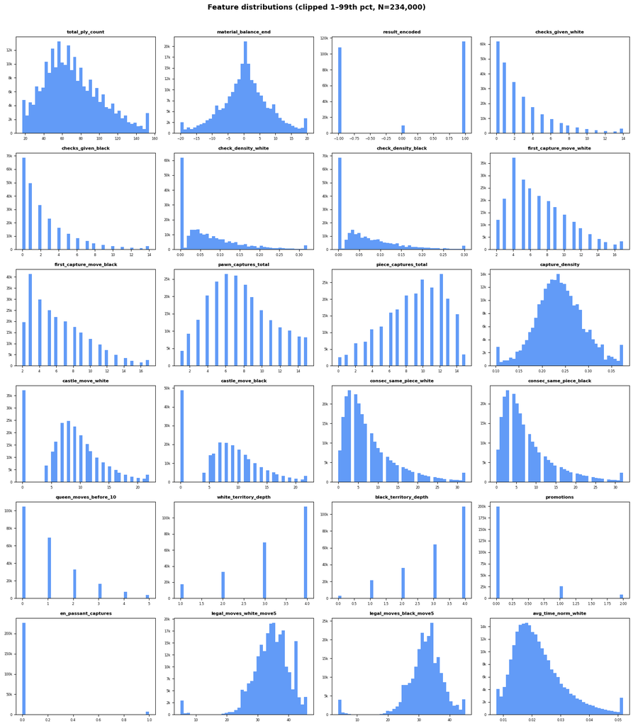

```
Feature distribution plot saved.
```

|  | WhiteElo | BlackElo | tc_base | tc_increment | total_ply_count | material_balance_end | result_encoded | checks_given_white | checks_given_black | check_density_white | ... | time_spent_trend_norm_white | avg_time_norm_black | std_time_norm_black | max_time_norm_black | time_pressure_black | opening_pace_norm_black | clock_remaining_norm_black | opening_time_norm_black | endgame_time_norm_black | time_spent_trend_norm_black |
| --- | --- | --- | --- | --- | --- | --- | --- | --- | --- | --- | --- | --- | --- | --- | --- | --- | --- | --- | --- | --- | --- |
| count | 234000.00 | 234000.00 | 234000.0 | 234000.00 | 234000.00 | 234000.00 | 234000.00 | 234000.00 | 234000.00 | 234000.00 | ... | 234000.00 | 234000.00 | 234000.00 | 234000.00 | 234000.00 | 234000.00 | 234000.00 | 234000.00 | 234000.00 | 234000.00 |
| mean | 1704.66 | 1704.76 | 180.0 | 0.49 | 71.25 | 0.06 | 0.03 | 2.71 | 2.51 | 0.07 | ... | 0.00 | 0.02 | 0.03 | 0.12 | 1.50 | 0.02 | 0.33 | 0.02 | 0.02 | 0.00 |
| std | 287.70 | 288.04 | 0.0 | 1.08 | 30.70 | 7.80 | 0.98 | 3.19 | 3.08 | 0.07 | ... | 0.00 | 0.01 | 0.02 | 0.09 | 3.91 | 0.01 | 0.29 | 0.01 | 0.02 | 0.00 |
| min | 773.00 | 769.00 | 180.0 | 0.00 | 12.00 | -64.00 | -1.00 | 0.00 | 0.00 | 0.00 | ... | -0.07 | 0.00 | 0.00 | 0.00 | 0.00 | 0.00 | 0.00 | 0.00 | 0.00 | -0.08 |
| 25% | 1506.00 | 1507.00 | 180.0 | 0.00 | 49.00 | -4.00 | -1.00 | 0.00 | 0.00 | 0.00 | ... | -0.00 | 0.02 | 0.02 | 0.07 | 0.00 | 0.01 | 0.08 | 0.01 | 0.01 | -0.00 |
| 50% | 1709.00 | 1709.00 | 180.0 | 0.00 | 67.00 | 0.00 | 0.00 | 2.00 | 1.00 | 0.05 | ... | 0.00 | 0.02 | 0.02 | 0.09 | 0.00 | 0.01 | 0.28 | 0.01 | 0.02 | 0.00 |
| 75% | 1900.00 | 1901.00 | 180.0 | 0.00 | 90.00 | 4.00 | 1.00 | 4.00 | 4.00 | 0.11 | ... | 0.00 | 0.03 | 0.03 | 0.14 | 0.00 | 0.02 | 0.54 | 0.02 | 0.03 | 0.00 |
| max | 2786.00 | 2787.00 | 180.0 | 30.00 | 298.00 | 64.00 | 1.00 | 51.00 | 54.00 | 0.80 | ... | 0.10 | 0.17 | 0.34 | 1.18 | 83.00 | 0.18 | 20.61 | 0.18 | 0.27 | 0.08 |

8 rows × 55 columns

```python
meta_cols = ['WhiteElo', 'BlackElo']
if FEATURE_GROUPS['meta']:
    meta_cols += ['TimeControl', 'ECO']
if ADD_TIME_CONTROL_NUMERIC:
    meta_cols += ['tc_base', 'tc_increment']
meta_cols = list(dict.fromkeys([c for c in meta_cols if c in df_raw.columns]))

df = (
    df_raw[meta_cols]
    .join(df_feats, how='inner')
    .join(df_clocks, how='inner')
)
df = df.replace([np.inf, -np.inf], np.nan)

if FEATURE_GROUPS['meta'] and ECO_COARSE_LEVEL == 'letter' and 'ECO' in df.columns:
    df['ECO_Group'] = df['ECO'].astype(str).str[0].fillna('U')

if FILTER_SHORT_GAMES and 'total_ply_count' in df.columns:
    before = len(df)
    df = df[df['total_ply_count'] >= MIN_TOTAL_PLIES].copy().reset_index(drop=True)
    print(f'After short-game filter (<{MIN_TOTAL_PLIES} plies): {len(df):,}  (dropped {before-len(df):,})')

_all_active = NUMERIC_FEATURES + CATEGORICAL_FEATURES
_missing    = [c for c in _all_active if c not in df.columns]
if _missing:
    print('WARNING — columns not found:', _missing)

print(f'Final DataFrame: {df.shape}')

# ── Feature distribution plots ─────────────────────────────────────────────────
if VERBOSE_PLOTS:
    _plot_feats = [f for f in NUMERIC_FEATURES if f in df.columns][:24]
    n_cols = 4
    n_rows = (len(_plot_feats) + n_cols - 1) // n_cols
    fig, axes = plt.subplots(n_rows, n_cols, figsize=(16, n_rows * 3))
    axes = axes.flatten()
    for ax, feat in zip(axes, _plot_feats):
        vals = df[feat].dropna()
        # clip extreme outliers for readability
        lo, hi = vals.quantile(0.01), vals.quantile(0.99)
        vals_c = vals.clip(lo, hi)
        ax.hist(vals_c, bins=40, color='#3b82f6', alpha=0.8, edgecolor='none')
        ax.set_title(feat, fontsize=8, fontweight='bold')
        ax.set_xlabel('')
        ax.tick_params(labelsize=6)
        ax.yaxis.set_major_formatter(mticker.FuncFormatter(lambda x, _: f'{int(x/1000)}k' if x >= 1000 else str(int(x))))
    for ax in axes[len(_plot_feats):]:
        ax.axis('off')
    plt.suptitle(f'Feature distributions (clipped 1–99th pct, N={len(df):,})',
                 fontsize=13, fontweight='bold', y=1.01)
    plt.tight_layout()
    plt.show()
    print('Feature distribution plot saved.')

df.describe().round(2)
```

## 7 · Preprocessing & feature matrix

```python
def build_preprocessor(numeric_cols, categorical_cols):
    transformers = [('num', SimpleImputer(strategy='median'), numeric_cols)]
    if categorical_cols:
        transformers.append(
            ('cat', OneHotEncoder(handle_unknown='ignore', sparse_output=False), categorical_cols)
        )
    return ColumnTransformer(transformers=transformers, remainder='drop')

_num_cols = [c for c in NUMERIC_FEATURES     if c in df.columns]
_cat_cols = [c for c in CATEGORICAL_FEATURES  if c in df.columns]

preprocessor = build_preprocessor(_num_cols, _cat_cols)
X_all        = preprocessor.fit_transform(df)
feat_names   = list(preprocessor.get_feature_names_out())

print(f'Feature matrix: {X_all.shape}  ({len(feat_names)} named features)')
```

```
Feature matrix: (234000, 49)  (49 named features)
```

## 8 · Train / Val / Test split + sample weights

> **Scaling note:** `compute_elo_sample_weights` uses inverse-frequency bins. When your data is large (millions), the 1200–1800 bucket is extremely dense while 2200+ is sparse — weights for top bins can exceed 20×. We clip at 8× to prevent a handful of high-Elo games from dominating training. Increase `WEIGHT_CLIP` if you want to stress high-Elo accuracy further.

```
Train : 187,200
Val   : 23,400
Test  : 23,400
```

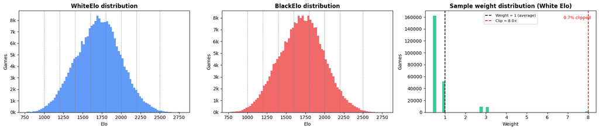

```
Weight stats (White): min=0.41  median=0.55  max=8.00    clipped=1,632 games
```

```python
WEIGHT_CLIP = 8.0  # max sample weight allowed; prevents high-Elo games from dominating

y_white = df['WhiteElo'].values
y_black = df['BlackElo'].values
idx     = np.arange(len(df))

idx_tv, idx_test = train_test_split(idx, test_size=TEST_SIZE, random_state=RANDOM_STATE)
_val_fraction    = VAL_SIZE / (1 - TEST_SIZE)
idx_train, idx_val = train_test_split(idx_tv, test_size=_val_fraction, random_state=RANDOM_STATE)

X_train, X_val, X_test = X_all[idx_train], X_all[idx_val], X_all[idx_test]

print(f'Train : {len(idx_train):,}')
print(f'Val   : {len(idx_val):,}')
print(f'Test  : {len(idx_test):,}')

# # ── dynamic ELO_BINS based on data percentiles ─────────────────────────────────
# _pct = np.percentile(df['WhiteElo'], [0, 10, 25, 50, 75, 90, 95, 99, 100])
# ELO_BINS = sorted(set([int(x) for x in _pct]))
# print(f'ELO_BINS (from percentiles): {ELO_BINS}')
_elo_min = int(df['WhiteElo'].min())
ELO_BINS = [_elo_min, 1200, 1400, 1600, 1800, 2000, 2200, 2500, 4000]

weights_white = np.clip(compute_elo_sample_weights(df['WhiteElo'], ELO_BINS), 0, WEIGHT_CLIP)
weights_black = np.clip(compute_elo_sample_weights(df['BlackElo'], ELO_BINS), 0, WEIGHT_CLIP)

# ── weight distribution plot ───────────────────────────────────────────────────
if VERBOSE_PLOTS:
    fig, axes = plt.subplots(1, 3, figsize=(18, 4))

    # Raw Elo histogram + bins
    for ax, col, color in zip(axes[:2], ['WhiteElo', 'BlackElo'], ['#3b82f6', '#ef4444']):
        ax.hist(df[col], bins=80, color=color, edgecolor='none', alpha=0.8)
        ax.set_title(f'{col} distribution', fontweight='bold')
        ax.set_xlabel('Elo'); ax.set_ylabel('Games')
        for b in ELO_BINS[1:-1]:
            ax.axvline(b, color='gray', lw=0.6, ls='--')
        ax.yaxis.set_major_formatter(mticker.FuncFormatter(lambda x, _: f'{int(x/1000)}k'))

    # Weight histogram
    ax = axes[2]
    ax.hist(weights_white, bins=50, color='#10b981', alpha=0.8, edgecolor='none')
    ax.axvline(1.0, color='black', lw=1.5, ls='--', label='Weight = 1 (average)')
    ax.axvline(WEIGHT_CLIP, color='red', lw=1.5, ls='--', label=f'Clip = {WEIGHT_CLIP}×')
    ax.set_title('Sample weight distribution (White Elo)', fontweight='bold')
    ax.set_xlabel('Weight'); ax.set_ylabel('Games')
    ax.legend(fontsize=8)
    pct_clipped = (weights_white == WEIGHT_CLIP).mean() * 100
    ax.text(0.97, 0.92, f'{pct_clipped:.1f}% clipped', transform=ax.transAxes,
            ha='right', fontsize=9, color='red')

    plt.tight_layout()
    plt.show()

_w_min, _w_max, _w_med = weights_white.min(), weights_white.max(), np.median(weights_white)
print(f'Weight stats (White): min={_w_min:.2f}  median={_w_med:.2f}  max={_w_max:.2f}  '
      f'  clipped={((weights_white==WEIGHT_CLIP).sum()):,} games')
```

## 9 · GPU check & optional auto-benchmark (GTX 970)

```python
_EFFECTIVE_GPU = False  # will be set True only if GPU wins benchmark

if USE_GPU:
    print('GPU mode requested — checking availability...')
    _GPU_OK = False

    # ── LightGBM GPU check ─────────────────────────────────────────────────
    if MODEL_BACKEND == 'lightgbm':
        try:
            import subprocess
            _result = subprocess.run(['nvidia-smi', '--query-gpu=name,memory.total',
                                      '--format=csv,noheader'], capture_output=True, text=True)
            if _result.returncode == 0:
                print(f'  GPU found: {_result.stdout.strip()}')
                _GPU_OK = True
            else:
                print('  nvidia-smi failed — GPU likely unavailable in this environment')
        except FileNotFoundError:
            print('  nvidia-smi not found')

    # ── XGBoost GPU check ──────────────────────────────────────────────────
    elif MODEL_BACKEND == 'xgboost':
        try:
            import xgboost as xgb
            _test = xgb.XGBRegressor(tree_method='gpu_hist', device='cuda', n_estimators=5, verbosity=0)
            _small = X_train[:1000]
            _test.fit(_small, y_white[idx_train[:1000]])
            print('  XGBoost GPU (CUDA) test passed ✓')
            _GPU_OK = True
        except Exception as e:
            print(f'  XGBoost GPU test failed: {e}')

    if _GPU_OK and GPU_AUTO_DISABLE:
        print('\nBenchmarking GPU vs CPU on 50k rows (3 trees)...')
        _N = min(50_000, len(X_train))
        _Xb, _yb = X_train[:_N], y_white[idx_train[:_N]]

        def _quick_fit(gpu: bool):
            if MODEL_BACKEND == 'lightgbm':
                p = dict(LGBM_PARAMS, n_estimators=3, verbose=-1)
                if gpu: p.update({'device': 'gpu', 'gpu_device_id': GPU_DEVICE_ID})
                m = lgb.LGBMRegressor(**p)
                t = time.time(); m.fit(_Xb, _yb); return time.time() - t
            else:
                p = dict(XGB_PARAMS, n_estimators=3, verbosity=0)
                if gpu: p.update({'device': 'cuda', 'tree_method': 'gpu_hist'})
                m = xgb.XGBRegressor(**p)
                t = time.time(); m.fit(_Xb, _yb, eval_set=[(_Xb, _yb)], verbose=False)
                return time.time() - t

        _t_cpu = _quick_fit(False)
        _t_gpu = _quick_fit(True) if _GPU_OK else float('inf')

        print(f'  CPU: {_t_cpu:.2f}s   GPU: {_t_gpu:.2f}s')
        if _t_gpu < _t_cpu * 0.9:
            print(f'  ✅ GPU is faster ({_t_gpu/_t_cpu:.2%} of CPU time) — enabling GPU')
            _EFFECTIVE_GPU = True
        else:
            print(f'  ⚠️  GPU not faster (ratio {_t_gpu/_t_cpu:.2%}) — falling back to CPU')
            _EFFECTIVE_GPU = False
    elif _GPU_OK:
        _EFFECTIVE_GPU = True

else:
    print('GPU disabled (USE_GPU=False) — using CPU')

print(f'\nEffective GPU: {_EFFECTIVE_GPU}')

# ── inject GPU params ──────────────────────────────────────────────────────────
_final_lgbm_params = dict(LGBM_PARAMS)
_final_xgb_params  = dict(XGB_PARAMS)

if _EFFECTIVE_GPU and MODEL_BACKEND == 'lightgbm':
    _final_lgbm_params.update({'device': 'gpu', 'gpu_device_id': GPU_DEVICE_ID})
    print('LightGBM GPU params injected')

if _EFFECTIVE_GPU and MODEL_BACKEND == 'xgboost':
    _final_xgb_params.update({'device': 'cuda', 'tree_method': 'gpu_hist'})
    print('XGBoost GPU params injected')
```

```
GPU mode requested — checking availability...
  GPU found: NVIDIA GeForce GTX 970, 4096 MiB

Effective GPU: True
LightGBM GPU params injected
```

## 10 · Hyperparameter search

Uses only `HYPERPARAM_SUBSET_FRACTION` of training data for speed.

```python
best_lgbm_params = _final_lgbm_params.copy()
best_xgb_params  = _final_xgb_params.copy()

if LOAD_PRETRAINED_MODELS:
    print('Hyperparam search skipped — using pretrained models')

elif RUN_HYPERPARAM_SEARCH:
    # sub-sample for speed
    _n_hp = max(1000, int(len(idx_train) * HYPERPARAM_SUBSET_FRACTION))
    _idx_hp, _ = train_test_split(idx_train, train_size=_n_hp, random_state=RANDOM_STATE)
    _Xhp = X_all[_idx_hp]
    _yhp = y_white[_idx_hp]
    _whp = weights_white[_idx_hp]
    print(f'Hyperparam search on {_n_hp:,} games ({HYPERPARAM_SUBSET_FRACTION*100:.0f}% of train)')

    if MODEL_BACKEND == 'lightgbm':
        _base = lgb.LGBMRegressor(random_state=RANDOM_STATE, verbose=-1, n_jobs=N_JOBS)
        _space = LGBM_SEARCH_SPACE
    else:
        _base = xgb.XGBRegressor(random_state=RANDOM_STATE, verbosity=0, n_jobs=N_JOBS,
                                  tree_method='hist')
        _space = XGB_SEARCH_SPACE

    search = RandomizedSearchCV(
        _base, _space,
        n_iter=HYPERPARAM_N_ITER, cv=HYPERPARAM_CV_FOLDS,
        scoring='neg_mean_absolute_error',
        n_jobs=1, random_state=RANDOM_STATE, verbose=1,
    )
    search.fit(_Xhp, _yhp, sample_weight=_whp)
    print('Best params:', search.best_params_)
    print(f'Best CV MAE: {-search.best_score_:.1f}')

    if MODEL_BACKEND == 'lightgbm':
        best_lgbm_params.update(search.best_params_)
    else:
        best_xgb_params.update(search.best_params_)

    # ── CV results plot ────────────────────────────────────────────────────
    _cv_df = pd.DataFrame(search.cv_results_)
    _cv_df['mean_mae'] = -_cv_df['mean_test_score']
    _cv_df = _cv_df.sort_values('mean_mae').head(10)
    fig, ax = plt.subplots(figsize=(10, 4))
    ax.barh(range(len(_cv_df)), _cv_df['mean_mae'].values[::-1],
            color='#3b82f6', alpha=0.8, edgecolor='none')
    ax.set_yticks(range(len(_cv_df)))
    ax.set_yticklabels([str(i) for i in range(len(_cv_df))], fontsize=8)
    ax.set_xlabel('CV MAE (lower = better)')
    ax.set_title('Top 10 hyperparameter configs', fontweight='bold')
    plt.tight_layout(); plt.savefig('/tmp/_hparam.png', dpi=100); plt.show()
else:
    print('Hyperparam search skipped — using config params')
    print('Current LGBM params:', best_lgbm_params)
```

```
Hyperparam search skipped — using config params
Current LGBM params: {'n_estimators': 800, 'learning_rate': 0.05, 'num_leaves': 127, 'min_child_samples': 50, 'subsample': 0.8, 'colsample_bytree': 0.8, 'random_state': 42, 'verbose': -1, 'n_jobs': -1, 'device': 'gpu', 'gpu_device_id': 0}
```

## 11 · Train

```python
_ts = datetime.now().strftime('%Y%m%d_%H%M%S')

def load_lgbm_model(model_path, params):
    model = lgb.LGBMRegressor(**params)
    model.booster_ = lgb.Booster(model_file=model_path)
    n_feats = model.booster_.num_feature()
    model._n_features = n_feats; model._n_features_in = n_feats
    return model

def run_experiment(target, y_all, weights, lgbm_params, xgb_params, backend):
    y_train_ = y_all[idx_train]; y_val_ = y_all[idx_val]; y_test_ = y_all[idx_test]
    w_train_ = weights[idx_train]

    t0 = time.time()
    if backend == 'lightgbm':
        model = lgb.LGBMRegressor(**lgbm_params)
        model.fit(
            X_train, y_train_, sample_weight=w_train_,
            eval_set=[(X_val, y_val_)],
            callbacks=[lgb.early_stopping(50, verbose=False), lgb.log_evaluation(100)],
        )
    else:
        _xp = dict(xgb_params)
        _xp.pop('early_stopping_rounds', None)
        model = xgb.XGBRegressor(**_xp, early_stopping_rounds=50)
        model.fit(X_train, y_train_, sample_weight=w_train_,
                  eval_set=[(X_val, y_val_)], verbose=100)

    train_time = time.time() - t0
    val_preds  = model.predict(X_val)
    test_preds = model.predict(X_test)
    val_mae    = mean_absolute_error(y_val_,  val_preds)
    test_mae   = mean_absolute_error(y_test_, test_preds)
    test_rmse  = root_mean_squared_error(y_test_, test_preds)

    print(f'{target} [{backend}] | Train: {train_time:.0f}s | Val MAE: {val_mae:.1f} '
          f'| Test MAE: {test_mae:.1f} | Test RMSE: {test_rmse:.1f}')

    fname = f'{MODEL_SAVE_NAME}_{MODEL_SAVE_NOTES}_{target.lower().replace(" ","_")}_{_ts}.txt'
    if backend == 'lightgbm':
        model.booster_.save_model(fname)
    else:
        model.save_model(fname)
    print(f'  Saved → {fname}')

    return dict(model=model, y_val=y_val_, y_test=y_test_,
                val_preds=val_preds, test_preds=test_preds,
                val_mae=val_mae, test_mae=test_mae, test_rmse=test_rmse,
                label=target, backend=backend, train_time=train_time)

def run_loaded(target, y_all, model):
    y_val_  = y_all[idx_val]; y_test_ = y_all[idx_test]
    val_preds  = model.predict(X_val)
    test_preds = model.predict(X_test)
    val_mae  = mean_absolute_error(y_val_,  val_preds)
    test_mae = mean_absolute_error(y_test_, test_preds)
    test_rmse= root_mean_squared_error(y_test_, test_preds)
    print(f'{target} (loaded)  |  Val MAE: {val_mae:.1f}  Test MAE: {test_mae:.1f}  RMSE: {test_rmse:.1f}')
    return dict(model=model, y_val=y_val_, y_test=y_test_,
                val_preds=val_preds, test_preds=test_preds,
                val_mae=val_mae, test_mae=test_mae, test_rmse=test_rmse,
                label=target, backend='loaded', train_time=0)

if LOAD_PRETRAINED_MODELS:
    white_model = load_lgbm_model(PRETRAINED_WHITE_PATH, best_lgbm_params)
    black_model = load_lgbm_model(PRETRAINED_BLACK_PATH, best_lgbm_params)
    white_run = run_loaded('WhiteElo', y_white, white_model)
    black_run = run_loaded('BlackElo', y_black, black_model)
else:
    white_run = run_experiment('WhiteElo', y_white, weights_white,
                               best_lgbm_params, best_xgb_params, MODEL_BACKEND)
    black_run = run_experiment('BlackElo', y_black, weights_black,
                               best_lgbm_params, best_xgb_params, MODEL_BACKEND)
```

```
WhiteElo [lightgbm] | Train: 22s | Val MAE: 203.0 | Test MAE: 201.7 | Test RMSE: 252.3
  Saved → elo_lightgbm_1000000_600s_scale_whiteelo_20260606_170729.txt
BlackElo [lightgbm] | Train: 9s | Val MAE: 201.6 | Test MAE: 201.4 | Test RMSE: 251.5
  Saved → elo_lightgbm_1000000_600s_scale_blackelo_20260606_170729.txt
```

## 12 · Feature importance

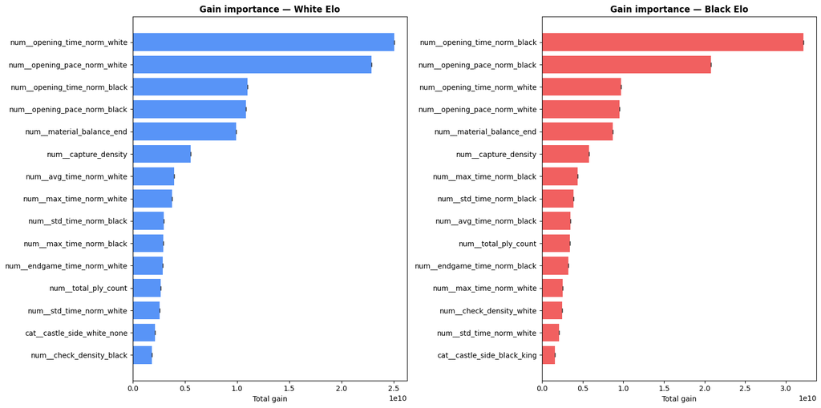

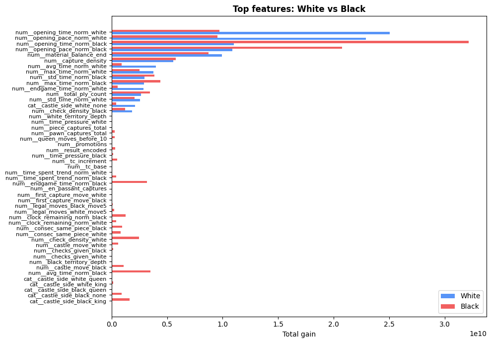

```
                     feature   importance  std
num__opening_time_norm_white 2.504041e+10  0.0
num__opening_pace_norm_white 2.287175e+10  0.0
num__opening_time_norm_black 1.101032e+10  0.0
num__opening_pace_norm_black 1.086787e+10  0.0
   num__material_balance_end 9.920620e+09  0.0
        num__capture_density 5.539713e+09  0.0
    num__avg_time_norm_white 3.976645e+09  0.0
    num__max_time_norm_white 3.784826e+09  0.0
    num__std_time_norm_black 2.954309e+09  0.0
    num__max_time_norm_black 2.935084e+09  0.0
num__endgame_time_norm_white 2.855817e+09  0.0
        num__total_ply_count 2.652587e+09  0.0
    num__std_time_norm_white 2.580435e+09  0.0
 cat__castle_side_white_none 2.106319e+09  0.0
    num__check_density_black 1.830746e+09  0.0
```

```python
perm_white = perm_black = None

if RUN_PERM_IMPORTANCE:
    _method = str(FEATURE_IMPORTANCE_METHOD).strip().lower()

    def compute_importance(run, method, n_repeats=PERM_N_REPEATS):
        if method == 'permutation':
            print(f'Permutation importance — {run["label"]} ({n_repeats} repeats)...')
            t0 = time.time()
            result = permutation_importance(
                run['model'], X_test, run['y_test'],
                n_repeats=n_repeats, scoring='neg_mean_absolute_error',
                n_jobs=N_JOBS, random_state=RANDOM_STATE,
            )
            print(f'  done in {time.time()-t0:.1f}s')
            n = len(feat_names)
            return pd.DataFrame({
                'feature':    feat_names[:n],
                'importance': result.importances_mean[:n],
                'std':        result.importances_std[:n],
            }).sort_values('importance', ascending=False).reset_index(drop=True)

        # gain / split — from booster
        backend = run.get('backend', 'lightgbm')
        if backend == 'lightgbm':
            booster = run['model'].booster_
            imps = booster.feature_importance(importance_type=method)
        else:
            imps = run['model'].get_booster().get_score(importance_type='gain' if method=='gain' else 'weight')
            # xgb returns a dict; align to feat_names
            imps = np.array([imps.get(f, 0) for f in feat_names])

        n = len(feat_names)
        return pd.DataFrame({
            'feature':    feat_names[:n],
            'importance': imps[:n],
            'std':        np.zeros(n, dtype=float),
        }).sort_values('importance', ascending=False).reset_index(drop=True)

    perm_white = compute_importance(white_run, _method)
    perm_black = compute_importance(black_run, _method)

    if VERBOSE_PLOTS:
        _xl = {'permutation': 'MAE decrease', 'gain': 'Total gain', 'split': 'Split count'}.get(_method, _method)
        _title_suf = {'permutation': 'Permutation', 'gain': 'Gain', 'split': 'Split'}.get(_method, '')

        fig, axes = plt.subplots(1, 2, figsize=(16, 8))
        for ax, perm, title, col in zip(axes, [perm_white, perm_black],
                                         ['White Elo', 'Black Elo'],
                                         ['#3b82f6', '#ef4444']):
            top = perm.head(TOP_N_FEATURES).iloc[::-1]
            ax.barh(top['feature'], top['importance'], xerr=top['std'],
                    color=col, ecolor='#333', capsize=3, alpha=0.85)
            ax.axvline(0, color='black', lw=0.8)
            ax.set_title(f'{_title_suf} importance — {title}', fontweight='bold')
            ax.set_xlabel(_xl)
        plt.tight_layout()
        plt.show()

        # White vs Black comparison
        merged = (
            perm_white.head(TOP_N_FEATURES).rename(columns={'importance': 'white'})
            .merge(perm_black.rename(columns={'importance': 'black'}), on='feature', how='outer')
            .fillna(0).set_index('feature')[['white', 'black']]
            .sort_values('white', ascending=True)
        )
        fig, ax = plt.subplots(figsize=(10, 7))
        x = np.arange(len(merged)); bw = 0.4
        ax.barh(x-bw/2, merged['white'], bw, label='White', color='#3b82f6', alpha=0.85)
        ax.barh(x+bw/2, merged['black'], bw, label='Black', color='#ef4444', alpha=0.85)
        ax.set_yticks(x); ax.set_yticklabels(merged.index, fontsize=8)
        ax.set_xlabel(_xl); ax.set_title('Top features: White vs Black', fontweight='bold')
        ax.legend(); plt.tight_layout()
        plt.show()

        print(perm_white.head(TOP_N_FEATURES).to_string(index=False))
else:
    print('Feature importance skipped (RUN_PERM_IMPORTANCE=False)')
```

## 13 · Retrain on top-N features (optional)

```python
if RETRAIN_TOP_N and perm_white is not None:
    top_feats = perm_white.head(TOP_N_FEATURES)['feature'].tolist()
    print(f'Retraining on top {TOP_N_FEATURES} features: {top_feats}')
    _top_idx = [feat_names.index(f) for f in top_feats if f in feat_names]
    X_top    = X_all[:, _top_idx]

    def run_top(target, y_all, weights, color):
        if MODEL_BACKEND == 'lightgbm':
            model = lgb.LGBMRegressor(**best_lgbm_params)
            model.fit(X_top[idx_train], y_all[idx_train], sample_weight=weights[idx_train],
                      eval_set=[(X_top[idx_val], y_all[idx_val])],
                      callbacks=[lgb.early_stopping(50, verbose=False), lgb.log_evaluation(period=0)])
        else:
            _xp = dict(best_xgb_params); _xp.pop('early_stopping_rounds', None)
            model = xgb.XGBRegressor(**_xp, early_stopping_rounds=50)
            model.fit(X_top[idx_train], y_all[idx_train], sample_weight=weights[idx_train],
                      eval_set=[(X_top[idx_val], y_all[idx_val])], verbose=False)
        preds     = model.predict(X_top[idx_test])
        test_mae  = mean_absolute_error(y_all[idx_test], preds)
        test_rmse = root_mean_squared_error(y_all[idx_test], preds)
        fname = f'{MODEL_SAVE_NAME}_{target.lower()}_top{TOP_N_FEATURES}_{_ts}.txt'
        if MODEL_BACKEND == 'lightgbm': model.booster_.save_model(fname)
        else: model.save_model(fname)
        print(f'{target} (top-{TOP_N_FEATURES})  |  Test MAE: {test_mae:.1f}  RMSE: {test_rmse:.1f}  → {fname}')
        return preds, y_all[idx_test], test_mae

    w_preds_top, w_true_top, w_mae_top = run_top('WhiteElo', y_white, weights_white, '#3b82f6')
    b_preds_top, b_true_top, b_mae_top = run_top('BlackElo', y_black, weights_black, '#ef4444')
else:
    print('Top-N retrain skipped')
```

```
Top-N retrain skipped
```

## 14 · Results & diagnostic plots

```
                  Model  Train time (s)  Val MAE  Test MAE  Test RMSE
Full — White [lightgbm]           22.07   202.99    201.74     252.28
Full — Black [lightgbm]            8.98   201.60    201.41     251.50
```

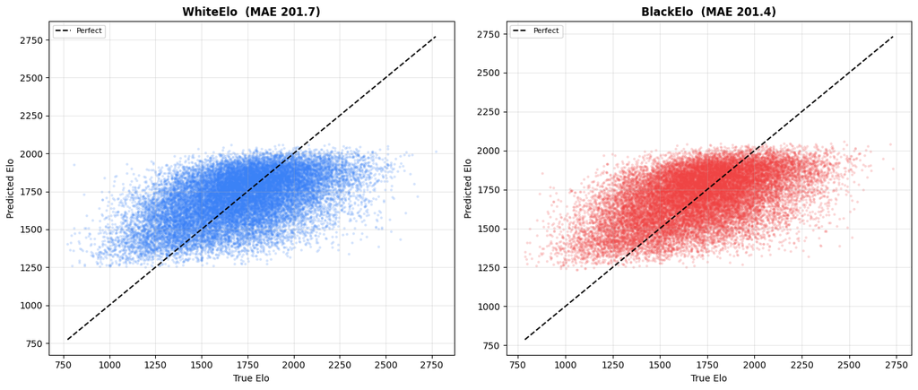

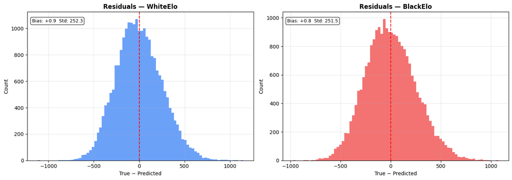

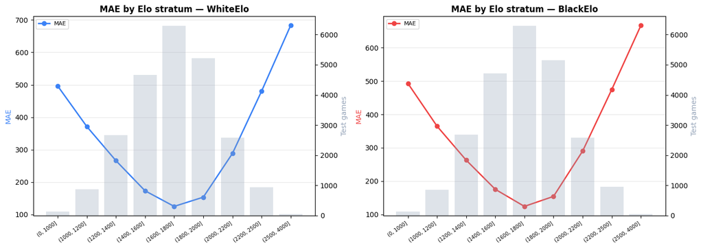

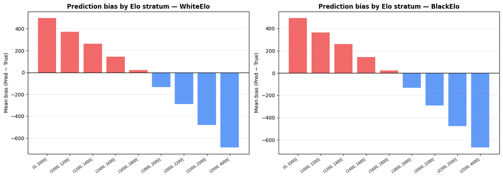

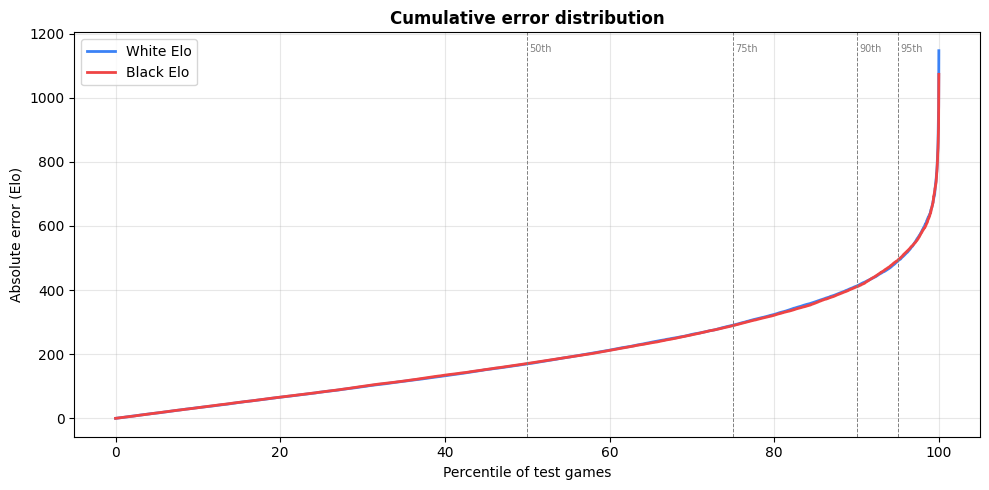

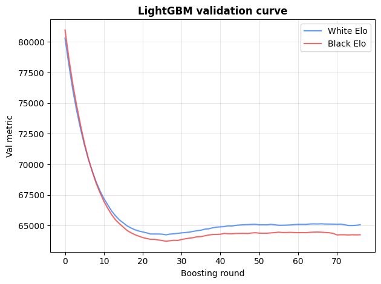

```
=== Final Summary ===
                  Model  Train time (s)  Val MAE  Test MAE  Test RMSE
Full — White [lightgbm]           22.07   202.99    201.74     252.28
Full — Black [lightgbm]            8.98   201.60    201.41     251.50
```

```python
# ── summary table ─────────────────────────────────────────────────────────────
_rows = [
    {'Model': f'Full — White [{MODEL_BACKEND}]',
     'Train time (s)': white_run['train_time'],
     'Val MAE': white_run['val_mae'], 'Test MAE': white_run['test_mae'],
     'Test RMSE': white_run['test_rmse']},
    {'Model': f'Full — Black [{MODEL_BACKEND}]',
     'Train time (s)': black_run['train_time'],
     'Val MAE': black_run['val_mae'], 'Test MAE': black_run['test_mae'],
     'Test RMSE': black_run['test_rmse']},
]
if RETRAIN_TOP_N and perm_white is not None:
    _rows += [
        {'Model': f'Top-{TOP_N_FEATURES} — White', 'Train time (s)': None,
         'Val MAE': None, 'Test MAE': w_mae_top, 'Test RMSE': None},
        {'Model': f'Top-{TOP_N_FEATURES} — Black', 'Train time (s)': None,
         'Val MAE': None, 'Test MAE': b_mae_top, 'Test RMSE': None},
    ]
_summary = pd.DataFrame(_rows).round(2)
print(_summary.to_string(index=False))

if VERBOSE_PLOTS:
    # ── 1. True vs Predicted scatter ───────────────────────────────────────
    fig, axes = plt.subplots(1, 2, figsize=(14, 6))
    for ax, run, col in zip(axes, [white_run, black_run], ['#3b82f6', '#ef4444']):
        y_t, y_p = run['y_test'], run['test_preds']
        lo, hi = min(y_t.min(), y_p.min()), max(y_t.max(), y_p.max())
        ax.scatter(y_t, y_p, alpha=0.15, s=4, color=col, rasterized=True)
        ax.plot([lo, hi], [lo, hi], 'k--', lw=1.5, label='Perfect')
        ax.set_xlabel('True Elo'); ax.set_ylabel('Predicted Elo')
        ax.set_title(f"{run['label']}  (MAE {run['test_mae']:.1f})", fontweight='bold')
        ax.legend(fontsize=8); ax.grid(alpha=0.3)
    plt.tight_layout()
    plt.show()

    # ── 2. Residual histograms ─────────────────────────────────────────────
    fig, axes = plt.subplots(1, 2, figsize=(14, 5))
    for ax, run, col in zip(axes, [white_run, black_run], ['#3b82f6', '#ef4444']):
        res = run['y_test'] - run['test_preds']
        ax.hist(res, bins=80, color=col, edgecolor='none', alpha=0.75)
        ax.axvline(0, color='red', lw=1.5, ls='--')
        ax.set_title(f"Residuals — {run['label']}", fontweight='bold')
        ax.set_xlabel('True − Predicted'); ax.set_ylabel('Count')
        _bias = res.mean()
        ax.text(0.02, 0.93, f'Bias: {_bias:+.1f}  Std: {res.std():.1f}',
                transform=ax.transAxes, fontsize=9, color='black',
                bbox=dict(boxstyle='round,pad=0.3', facecolor='white', alpha=0.8))
        ax.grid(alpha=0.3)
    plt.tight_layout()
    plt.show()

    # ── 3. MAE by Elo stratum ──────────────────────────────────────────────
    fig, axes = plt.subplots(1, 2, figsize=(14, 5))
    for ax, run, elo_col, col in zip(axes, [white_run, black_run],
                                      ['WhiteElo', 'BlackElo'], ['#3b82f6', '#ef4444']):
        true_elo = df[elo_col].values[idx_test]
        strata   = pd.cut(true_elo, bins=ELO_BINS)
        mae_s    = pd.Series(np.abs(run['y_test'] - run['test_preds']))                      .groupby(strata, observed=True).mean()
        count_s  = pd.Series(run['y_test']).groupby(strata, observed=True).count()
        ax2 = ax.twinx()
        ax2.bar(range(len(count_s)), count_s.values, color='#94a3b8', alpha=0.3, label='Count')
        ax2.set_ylabel('Test games', color='#94a3b8')
        ax.plot(range(len(mae_s)), mae_s.values, 'o-', color=col, lw=2, ms=6, label='MAE')
        ax.set_xticks(range(len(mae_s)))
        ax.set_xticklabels([str(b) for b in mae_s.index], rotation=35, ha='right', fontsize=7)
        ax.set_ylabel('MAE', color=col)
        ax.set_title(f"MAE by Elo stratum — {run['label']}", fontweight='bold')
        ax.grid(axis='y', alpha=0.3)
        ax.legend(loc='upper left', fontsize=8)
    plt.tight_layout()
    plt.show()

    # ── 4. Prediction bias by Elo stratum ──────────────────────────────────
    fig, axes = plt.subplots(1, 2, figsize=(14, 5))
    for ax, run, elo_col, col in zip(axes, [white_run, black_run],
                                      ['WhiteElo', 'BlackElo'], ['#3b82f6', '#ef4444']):
        true_elo = df[elo_col].values[idx_test]
        strata   = pd.cut(true_elo, bins=ELO_BINS)
        bias_s   = pd.Series(run['test_preds'] - run['y_test'])                      .groupby(strata, observed=True).mean()
        colors_  = ['#ef4444' if v > 0 else '#3b82f6' for v in bias_s.values]
        ax.bar(range(len(bias_s)), bias_s.values, color=colors_, alpha=0.8, edgecolor='none')
        ax.axhline(0, color='black', lw=1)
        ax.set_xticks(range(len(bias_s)))
        ax.set_xticklabels([str(b) for b in bias_s.index], rotation=35, ha='right', fontsize=7)
        ax.set_ylabel('Mean bias (Pred − True)')
        ax.set_title(f"Prediction bias by Elo stratum — {run['label']}", fontweight='bold')
        ax.grid(axis='y', alpha=0.3)
    plt.tight_layout()
    plt.show()

    # ── 5. Error percentile plot ───────────────────────────────────────────
    fig, ax = plt.subplots(figsize=(10, 5))
    for run, col, lbl in zip([white_run, black_run], ['#3b82f6', '#ef4444'],
                               ['White Elo', 'Black Elo']):
        abs_errs = np.sort(np.abs(run['test_preds'] - run['y_test']))
        pcts = np.linspace(0, 100, len(abs_errs))
        ax.plot(pcts, abs_errs, color=col, lw=2, label=lbl)
    for q in [50, 75, 90, 95]:
        ax.axvline(q, color='gray', lw=0.7, ls='--')
        ax.text(q+0.3, ax.get_ylim()[1]*0.95, f'{q}th', fontsize=7, color='gray')
    ax.set_xlabel('Percentile of test games'); ax.set_ylabel('Absolute error (Elo)')
    ax.set_title('Cumulative error distribution', fontweight='bold')
    ax.legend(); ax.grid(alpha=0.3)
    plt.tight_layout()
    plt.show()

    # ── 6. LightGBM learning curves (if available) ────────────────────────
    if MODEL_BACKEND == 'lightgbm' and not LOAD_PRETRAINED_MODELS:
        try:
            for run, col, lbl in zip([white_run, black_run], ['#3b82f6', '#ef4444'],
                                      ['White Elo', 'Black Elo']):
                evals = run['model'].evals_result_
                if evals:
                    key = list(evals.keys())[-1]
                    metric_key = list(evals[key].keys())[0]
                    vals = evals[key][metric_key]
                    plt.plot(vals, color=col, alpha=0.8, label=lbl)
            plt.xlabel('Boosting round'); plt.ylabel('Val metric')
            plt.title('LightGBM validation curve', fontweight='bold')
            plt.legend(); plt.grid(alpha=0.3)
            plt.tight_layout(); plt.show()
        except Exception:
            pass

print('\n=== Final Summary ===')
print(_summary.to_string(index=False))
```

## 15 · Export notebook to HTML

Run this cell after execution to capture all plots and outputs.

```python
import subprocess, sys, os

def export_notebook_to_html(nb_path: str | None = None):
    """Convert this notebook to a self-contained HTML file with all outputs embedded."""
    if nb_path is None:
        # Try to detect running notebook path
        try:
            import ipykernel, json as _json
            _conn_file = ipykernel.get_connection_file()
            _kname = os.path.basename(_conn_file).replace('.json', '')
            import glob
            _nbs = glob.glob('**/*.ipynb', recursive=True)
            nb_path = _nbs[0] if _nbs else None
        except Exception:
            nb_path = None

    if nb_path is None:
        print('Could not detect notebook path automatically.')
        print('Run manually:  jupyter nbconvert --to html --no-input YOUR_NOTEBOOK.ipynb')
        return

    out_dir = os.path.dirname(os.path.abspath(nb_path))
    cmd = [
        sys.executable, '-m', 'nbconvert',
        '--to', 'html',
        '--output-dir', out_dir,
        nb_path,
    ]
    print(f'Exporting: {nb_path}')
    result = subprocess.run(cmd, capture_output=True, text=True)
    if result.returncode == 0:
        html_name = os.path.splitext(os.path.basename(nb_path))[0] + '.html'
        print(f'✅ Exported to {os.path.join(out_dir, html_name)}')
    else:
        print('Export error:', result.stderr[-500:])
        print('Tip: jupyter nbconvert --to html --no-input <your_notebook>.ipynb')

# ── Auto-export if enabled ─────────────────────────────────────────────────────
if EXPORT_HTML:
    export_notebook_to_html()
else:
    print('HTML export disabled (EXPORT_HTML=False)')
    print('Run export_notebook_to_html("<path>.ipynb") manually when ready.')
```

```
Exporting: chess_elo_v2_scale.ipynb
✅ Exported to c:\Users\villa\Desktop\Masters\AppML_FinalProject\root\workspace\villads_sandbox\chess_elo_v2_scale.html
```